# P8130_HW2_ym2771

Yuqi Miao

9/30/2019

```r
library(tidyverse)
library(readxl)
```

# Problem 1

## a) For all populations:

Use random variable X to denote The number of people have uveal melanoma in the US:
$$X\sim binomial(8.5\times10^6,\;5\times10^{-6})$$
$$P(X = 30) = \begin{pmatrix}N\\k\end{pmatrix}p^kq^{n-k} =0.00934$$

## b) For different races:

### For Asians

Use random variable $X_A$ to denote The number of people have uveal melanoma in the US:
$$X_A\sim binomial(1.19\times10^6,\;0.39\times10^{-6})$$
$$P(X_A = 30) = \begin{pmatrix}N\\k\end{pmatrix}p^kq^{n-k} =2.36\times10^{-43}$$
### For Blacks

Use random variable $X_B$ to denote The number of people have uveal melanoma in the US:
$$X_B\sim binomial(2.0655\times10^6,\;0.31\times10^{-6})$$
$$P(X_B = 30) = \begin{pmatrix}N\\k\end{pmatrix}p^kq^{n-k} =3.09\times10^{-39}$$

### For non-Hispanic White

Use random variable $X_N$ to denote The number of people have uveal melanoma in the US:
$$X_N\sim binomial(3.638\times10^6,\;6.02\times10^{-6})$$
$$P(X_A = 30) = \begin{pmatrix}N\\k\end{pmatrix}p^kq^{n-k} =0.019$$

# Problem 2

## a) t

### For intervention group:

- This test focuses on the BMI changes of intervention groups between baseline and 6 months follow-up groups.The parameter of interest is $\overline d\;=\;X_1-X_2$.
- Hypothesis:

$$H_0: \overline d\;=\;X_1-X_2\;=\;0$$
$$H_1:\overline d\;=\;X_1-X_2\;\neq\;0$$

- For this test is using to tell the difference of same objects at different time, it fits the condition of a paired t test, and because we don’t focus on only one side of the problem, this is a 2-side hypothesis test. The significance value is $\alpha = 0.05$

$$t_{stat}\;=\;\frac{\overline d}{s/\sqrt n}\;=\;\frac{-0.76}{1.44/\sqrt{36}}\;=\;-3.17$$

$$P_r(t<t_{stat,\;35})\;=\;2\times P(t<-3.17)\;=\;0.003<\;\alpha = 0.05$$
Thus, reject $H_0$, which means the difference between baseline and 6 months follow-up of intervention group is **significantly different from 0**, i.e., there is reason to **believe that difference between baseline and 6 months follow-up of intervention group exists**.

### For control group:

- This test focuses on the BMI changes of control groups between baseline and 6 months follow-up groups.The parameter of interest is $\overline d\;=\;X_1-X_2$.
- Hypothesis:

$$H_0: \overline d\;=\;X_1-X_2\;=\;0$$
$$H_1:\overline d\;=\;X_1-X_2\;\neq\;0$$

- For this test is using to tell the difference of same objects at different time, it fits the condition of a paired t test. and the significance value is $\alpha = 0.05$

$$t_{stat}\;=\;\frac{\overline d}{s/\sqrt n}\;=\;\frac{0.28}{0.97/\sqrt{36}}\;=\;1.73$$

$$P_r(t<t_{stat})\;=\;2\times P(t>1.73)\;=\;0.09 >\alpha = 0.05,\;df = 35$$
Thus, we don’t have enough evidence to reject $H_0$, which means the difference between baseline and 6 months follow-up of control group is **not significantly different from 0**, i.e., there is no reason to believe that there is difference between baseline and 6 months follow-up of the BMI of control group.

## b)

- This test focuses on the BMI changes between intervention and control groups. The interested parameter is $\Delta\;=\;{\overline X}_1-\;{\overline X}_2$;
- Because two groups are independent and the population variation $\sigma^2$ is unknown, we need to use F-test to tell if $\sigma_1^2$ and $\sigma_2^2$ are significantly different.
- Hypothesis for f test:

$$H_0: F =\frac{\sigma_1^2}{\sigma_2^2} = 1$$
$$H_0: F =\frac{\sigma_1^2}{\sigma_2^2} \neq 1$$

- Calculate the statistics and p-value:

- Thus reject $H_0$, which means $\sigma_1^2$ is not equal to $\sigma_2^2$, under this circumstances, the t test of control and intervention groups should be:
- Hypothesis For t test:

$$H_0: \Delta\;=\;X_1-X_2\;=\;0$$

$$H_1:\Delta\;=\;X_1-X_2\;\neq\;0$$

- Calculate the statistics:

- reject $H_0$, which means there are significant difference between the BMI of control and intervention group.

## c)

### What are the main underlying assumptions for the tests performed in parts a) and b)?

1. **Two tests in a) are all paired T tests**.

**For intervention group**, the underlying assumptions is that the BMI of the overweight/obese low-income virally suppressed HIV positive subjects who are willing to accept intervention at baseline is normally distributed with mean 31.97 and variance 43.27 and at follow-up group with mean 31.97+$\Delta$ and variance 43.27.

**For control group**, the underlying assumptions is that the BMI of the overweight/obese low-income virally suppressed HIV positive subjects who are not willing to accept intervention at baseline is normally distributed with mean 34.23 and variance 38 and at follow-up group with mean 34.23+$\Delta$ and variance 38

2. **Test in b) is independent T test**. the underlying assumptions is that the difference of BMI of the overweight/obese low-income virally suppressed HIV positive subjects who are willing to accept intervention between baseline and follow-up is normally distributed with mean -0.76 and variance 2.07 , and at the difference of control group with mean 0.28+$\Delta$ and variance 0.94.
3. Use graphical displays to check the normality assumption and discuss the findings.
2. If normality is questionable, how does this affect the tests validity and what are some possible remedies?

[figure not shown]

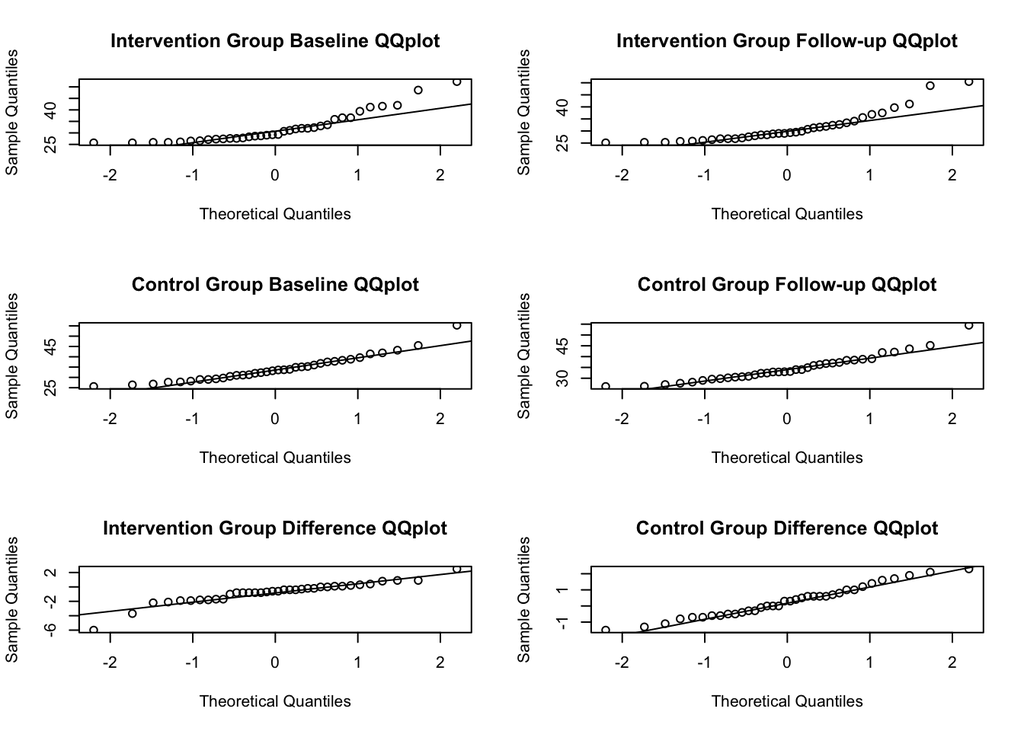

```r
plot_names_qq <- c("Intervention Group Baseline QQplot","Intervention Group Follow-up QQplot","Control Group Baseline QQplot", "Control Group Follow-up QQplot","Intervention Group Difference QQplot","Control Group Difference QQplot")
par(mfrow = c(3,2))
for (i in 1:6) {
    x <- plot_data[,i]
    qqnorm(x,main = plot_names_qq[i])
    qqline(x)
}
```

# Problem 3

$X$ is the number of closed restraunts in New York.

# Problem 4